# Risk factors for Cardiovascular Disease amongst midlife women

Weill Cornell Pediatrics Biostatistics Internship Analysis

**Biostatistician:** Mecca Love, Saribel Ufret Estrada

**Principal Investigator:** Yongkang Zhang, PhD

*July 21, 2026*

# Study Background

Cardiovascular disease remains the leading cause of death among women, yet women’s cardiovascular risk is often under-recognized during midlife and the menopausal transition. Menopause is associated with changes in cardiometabolic risk, including blood pressure, weight, lipids, glucose metabolism, sleep, physical activity, and mental health. However, existing cardiovascular risk prediction tools often do not fully incorporate women-specific life-course factors, social determinants of health, behavioral risk factors, or multimodal data sources.

The NIH All of Us Research Program provides a unique opportunity to study cardiovascular risk among midlife and postmenopausal women by combining electronic health records, surveys, physical measurements, medication data, laboratory results, social and behavioral measures, and potentially wearable and genomic data. The goal of this project was to construct a well-characterized cohort of midlife and postmenopausal women in All of Us and describe cardiovascular risk factors, menopause-related characteristics, social/behavioral risk factors, and candidate outcomes for future prediction model.

Following data exploration and dataset construction, the following primary analytical aims were identified:

# Aims

1. Identify a cohort of midlife women who responded to the All of Us menopause status survey question, and describe patient characteristics overall and by menopause status.
2. Use propensity score analysis to obtain an age-matched cohort of pre- and post-menopausal women to explore CVD outcomes by menopause exposure.
3. Bivariate crude analysis of CVD endpoints and menopause status (pre vs. post) amongst the matched cohort including prevalence of CVD at baseline (menopause survey response date), incidence of CVD within 1-year post menopause survey response, and time-to-CVD development.
4. Perform Cox multivariable modeling to obtain hazard ratio of menopause status on time-to-CVD, clustering by matched pair ID.
5. Perform LASSO modeling to explore variable importance of CVD predictors amongst midlife women, including menopause status.
6. Perform LASSO modeling to explore variable importance of CVD predictors stratified by pre- vs. post-menopause status to explore the extent to which menopause modifies CVD risk factors.

# Methods

This retrospective cohort study utilized data from the All of Us Research Program. Participants were categorized as pre-menopausal or post-menopausal based on survey responses. Nearest-neighbor propensity score matching was performed on age to create comparable cohorts of pre- and post-menopausal women.

Baseline characteristics were summarized using descriptive statistics and compared between groups using bivariate hypothesis tests (Fisher’s exact tests, Wilcoxon rank sum tests). Cardiovascular disease prevalence and one-year incidence were compared between menopause groups. Kaplan–Meier survival analysis was used to visualize and compare time to incident cardiovascular disease, and Cox proportional hazards regression estimated the association between menopausal status and time to incident cardiovascular disease. LASSO regression models were developed to identify the most important predictors of incident cardiovascular disease overall including menopause status as a predictor, and separately among pre- and post-menopausal women.

# Results

In the initial pre-matched cohort, there are **271,372 women** in All of Us who responded to the menopause question, are biologically female, and have EHR data, from which **161,241 reported post-menopause status** and **110,131 reported being pre-menopausal**. This cohort has notable imbalance, with a median age of 61 (IQR: 54, 69) in the post-menopause group vs 35 (IQR: 28, 43) in the pre-menopause group. To parse out menopause specific effects on CVD risk and outcomes, we will perform propensity score matching, matching solely on age and imposing a caliper of 0.05 to ensure two age-balanced groups.

## Baseline Characteristics of the Age-Matched Cohort

Following age matching, the study cohort included **72,366 women**, with **36,183 post-menopausal** and **36,183 pre-menopausal** participants. Although age distributions were similar between groups, post-menopausal women demonstrated significantly higher prevalences of hypertension, diabetes, chronic kidney disease, baseline cardiovascular disease, smoking, anxiety, depression, and food insecurity compared with pre-menopausal women (all *p* < 0.05).

| **Characteristic** | **Overall** N = 72,366 | **Post-menopause** N = 36,183 | **Pre-menopause** N = 36,183 | **p-value** |
| --- | --- | --- | --- | --- |
| **Age at survey** | 46 (38, 50) | 46 (38, 50) | 46 (38, 50) | <0.001 |
| **Combined race/ethnicity** |  |  |  | <0.001 |
| Asian | 2,219 (3.1%) | 806 (2.2%) | 1,413 (3.9%) |  |
| Hispanic or Latino | 16,302 (23%) | 7,307 (20%) | 8,995 (25%) |  |
| Non-Hispanic Black | 12,269 (17%) | 5,723 (16%) | 6,546 (18%) |  |
| Non-Hispanic White | 35,292 (49%) | 19,103 (53%) | 16,189 (45%) |  |
| Other | 6,284 (8.7%) | 3,244 (9.0%) | 3,040 (8.4%) |  |
| **Baseline hypertension** | 20,218 (28%) | 11,105 (31%) | 9,113 (25%) | <0.001 |
| **Baseline dyslipidemia** | 650 (0.9%) | 372 (1.0%) | 278 (0.8%) | <0.001 |
| **Baseline diabetes** | 10,430 (14%) | 5,551 (15%) | 4,879 (13%) | <0.001 |
| **Baseline CKD** | 2,414 (3.3%) | 1,430 (4.0%) | 984 (2.7%) | <0.001 |
| **History of pregnancy complications** | 286 (0.4%) | 122 (0.3%) | 164 (0.5%) | 0.013 |
| **Baseline depression** | 10,857 (73%) | 6,082 (76%) | 4,775 (71%) | <0.001 |
| **History of postpartum depression** | 1,722 (19%) | 929 (19%) | 793 (20%) | 0.2 |
| **Baseline anxiety** | 10,389 (69%) | 5,855 (72%) | 4,534 (66%) | <0.001 |
| **Having foregone care due to cost in the past year** | 17,708 (51%) | 9,871 (55%) | 7,837 (47%) | <0.001 |
| **Smoking status: Yes** | 24,132 (34%) | 13,466 (38%) | 10,666 (30%) | <0.001 |
| **Insurance status: Insured** | 66,648 (94%) | 33,533 (95%) | 33,115 (93%) | <0.001 |
| **Education** |  |  |  | <0.001 |
| College graduate | 30,781 (43%) | 14,144 (40%) | 16,637 (47%) |  |
| High school graduate | 12,813 (18%) | 6,720 (19%) | 6,093 (17%) |  |
| Less than a high school degree | 6,758 (9.5%) | 3,218 (9.1%) | 3,540 (10%) |  |
| Some college | 20,525 (29%) | 11,397 (32%) | 9,128 (26%) |  |
| **Income** |  |  |  | <0.001 |
| less 10k | 10,061 (17%) | 5,438 (18%) | 4,623 (16%) |  |
| 10k 25k | 8,258 (14%) | 4,537 (15%) | 3,721 (13%) |  |
| 25k 35k | 5,225 (8.8%) | 2,789 (9.2%) | 2,436 (8.4%) |  |
| 35k 50k | 5,818 (9.8%) | 3,118 (10%) | 2,700 (9.3%) |  |
| 50k 75k | 7,414 (12%) | 3,857 (13%) | 3,557 (12%) |  |
| 75k 100k | 5,858 (9.9%) | 3,002 (9.9%) | 2,856 (9.8%) |  |
| 100k 150k | 7,656 (13%) | 3,701 (12%) | 3,955 (14%) |  |
| 150k 200k | 3,964 (6.7%) | 1,781 (5.9%) | 2,183 (7.5%) |  |
| more 200k | 5,203 (8.8%) | 2,130 (7.0%) | 3,073 (11%) |  |
| **Marital status** |  |  |  | <0.001 |
| Divorced/Separated/Widowed | 15,549 (24%) | 8,464 (26%) | 7,085 (22%) |  |
| Married | 30,849 (48%) | 15,062 (47%) | 15,787 (49%) |  |
| Never Married | 18,100 (28%) | 8,784 (27%) | 9,316 (29%) |  |
| **Surgical menopause: Yes** | 1,479 (2.0%) | 1,233 (3.4%) | 246 (0.7%) | <0.001 |
| **BMI** | 30 (25, 36) | 31 (25, 37) | 29 (25, 36) | <0.001 |
| **Systolic BP** | 119 (110, 131) | 119 (110, 131) | 119 (110, 130) | 0.2 |
| **Diastolic BP** | 78 (70, 85) | 78 (71, 86) | 77 (70, 85) | <0.001 |
| **Food insecurity** | 7,094 (21%) | 4,286 (24%) | 2,808 (18%) | <0.001 |

## CVD outcomes

### Baseline and incident CVD within 1-year following menopause survey completion

| **Characteristic** | **Overall** N = 72,366 | **Post-menopause** N = 36,183 | **Pre-menopause** N = 36,183 | **p-value** |
| --- | --- | --- | --- | --- |
| Incident CVD within 1 year | 1,296 (2.0%) | 745 (2.4%) | 551 (1.7%) | <0.001 |
| Baseline CVD | 9,041 (12%) | 5,234 (14%) | 3,807 (11%) | <0.001 |

Within the matched cohort, baseline cardiovascular disease was more common among post-menopausal women than pre-menopausal women (14% vs. 11%, *p* < 0.001). Incident cardiovascular disease within one year also occurred more frequently among post-menopausal women (2.4% vs. 1.7%, *p* < 0.001), suggesting a greater short-term cardiovascular risk following menopause.

### Time to incident CVD

#### Kaplan-Meier curve

**Figure 1. Kaplan–Meier survival curve comparing time to incident cardiovascular disease among pre- and post-menopausal women.**

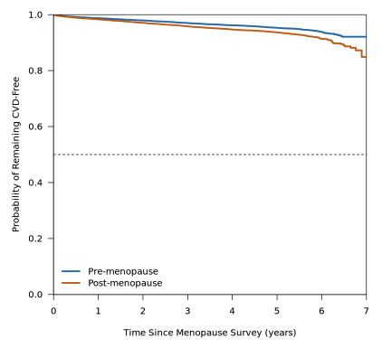

Kaplan–Meier survival analysis demonstrated a lower probability of remaining free of cardiovascular disease over time among post-menopausal women compared with pre-menopausal women, indicating a higher cumulative incidence of cardiovascular disease during follow-up.

#### Cox proportional hazards modeling

The Cox proportional hazards model demonstrated that post-menopausal women had a **39% higher instantaneous hazard of developing cardiovascular disease** compared with pre-menopausal women (HR = 1.39, 95% CI: 1.29–1.51, *p* < 0.001).

| Exposure | HR (95% CI) | P-value |
| --- | --- | --- |
| Post- vs. Pre-menopause | 1.39 (1.29–1.51) | <0.001 |

### LASSO modeling to assess relative variable importance

In the following sections, Least Absolute Shrinkage and Selection Operator (LASSO) modeling is used to perform regression in the setting of regularization to facilitate shrinkage of unimportant covariates to zero, functionally performing variable selection. LASSO modeling is performed to evaluate the relative importance of CVD risk factors amongst midlife women overall and stratified by menopause status. Note that for the following models, a lambda parameter 0.95 times the optimal model lambda (with respect to minimizing cross-validated errors) was applied to explore a more generous (not quite so aggressively shrunk) subset of predictors.

Variable importance plots are displayed below for each LASSO model to visually explore the relative importance of various CVD risk factors. Menopause is considered as a factor within the model including all women.

#### All women

**Figure 2A. LASSO variable importance plot for predictors of incident cardiovascular disease within one year among all women, considering menopause status as a predictor**

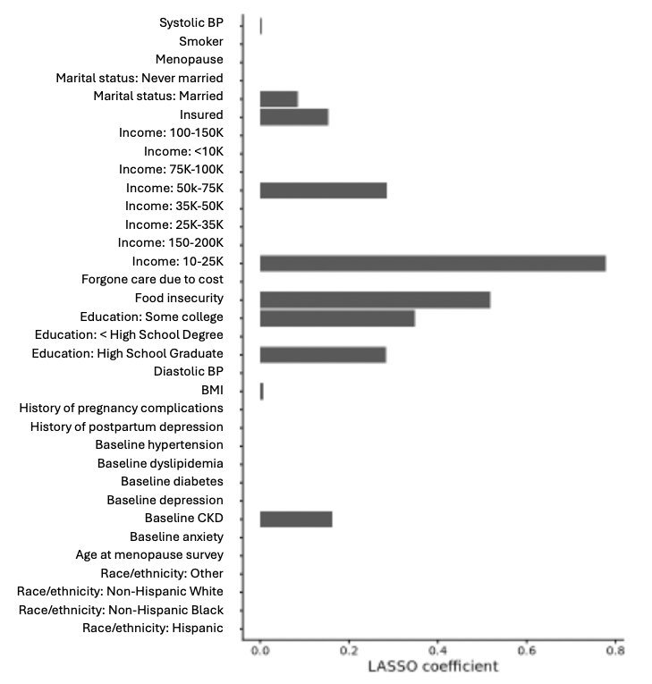

Important predictors identified in the above LASSO model include:

- Low income
- Self-reported food insecurity
- Low educational attainment
- Baseline CKD
- Insurance
- Marital status

Note that menopause was not selected as a predictor, nor was it selected in other model interations with progressively smaller and smaller lambda shrinkage penalties, indicating its relative unimportance compared to commonly known CVD risk factors.

#### LASSO Variable Importance: Pre-Menopausal Women

**Figure 2B. LASSO variable importance plot for predictors of incident cardiovascular disease within one year among pre-menopausal women**

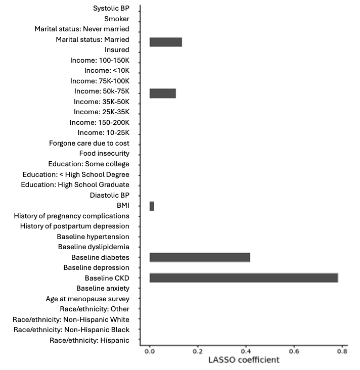

When limiting to pre-menopausal women, important risk factors include baseline CKD and diabetes. Additionally relevant factors include income and marital status.

#### LASSO Variable Importance: Post-Menopausal Women

**Figure 2C. LASSO variable importance plot for predictors of incident cardiovascular disease within one year among post-menopausal women**

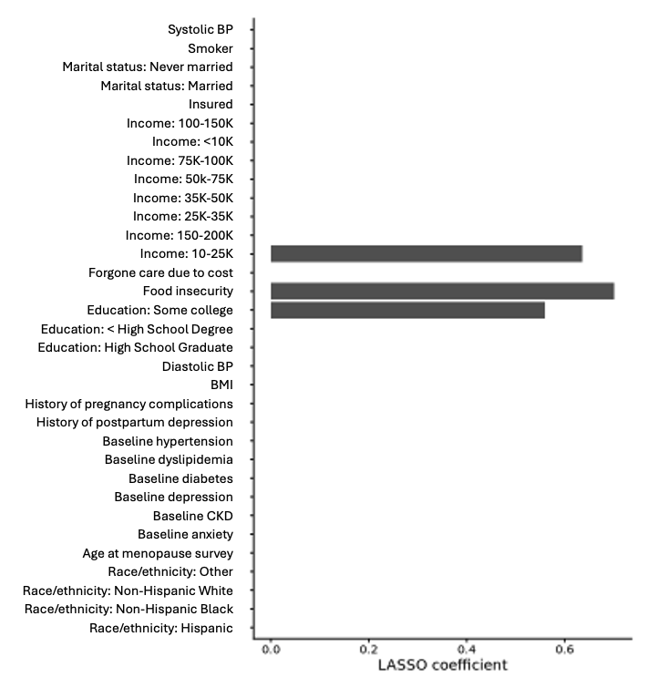

Amongst post-menopausal women, risk factors largely reflect socioeconomic status and include low income status, self-reported food insecurity, and education.

# Key Findings and Discussion

Following age-matched propensity score matching, post-menopausal women demonstrated a greater burden of cardiovascular risk factors and experienced significantly higher rates of both prevalent and incident cardiovascular disease within 1-year compared with pre-menopausal women. Kaplan–Meier survival analysis demonstrated lower cardiovascular disease-free survival among post-menopausal women, and Cox proportional hazards regression indicated a 39% higher hazard of incident cardiovascular disease (HR = 1.39, 95% CI: 1.29–1.51, p < 0.001) amongst post-menopausal women as compared to pre-.

LASSO regression identified the variables that contributed most strongly to predicting cardiovascular disease within each menopause group, providing insight into differences in cardiovascular risk profiles. Collectively, these findings suggest that menopause is associated with an increased burden of cardiovascular disease and provide insight into differences in cardiovascular risk profiles between pre- and post-menopausal women.

Division of Biostatistics

Department of Population Health Sciences

Mecca Love, Saribel Ufret Estrada